# Part 3 liquidCNA

Dohun Lee

01/06/2022

This is a quick R Markdown document going through the steps of liquidCNA pipeline for one patient. We will go through each function of the package exploring the maths being done, assumptions being made and defaults being used.

The pipeline of liquidCNA is as following:

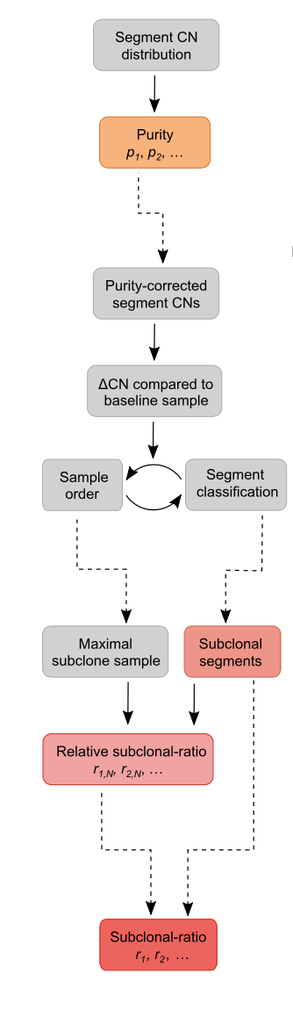

We will go through each of these step-by-step

# 1. Segment CN distribution

## 1.1 First, we load the outputs of QDNA…

The input into liquidCNA are two outputs from QDNAseq. QDNAseq is an R package for copy number analysis. ctDNA for each of the time points from each of our patients are sequence at 0.1x coverage with lpWGS. These sequencing reads are stored in fastq files. The reads are aligned to hg38 reference genome and the alignment mapping are stored in BAM files. QDNAseq bins the referenced hg38 genome (**in our case by 500kb annotation genome, recommended by the liquidCNA pipeline**), then from the BAM files, counts the number of reads that are mapped to each bin. The read counts are filtered and corrected by blacklist regions in the genome, GC content and mappability. From this QDNAseq then determine the copy number aberration. From here the first output of QDNAseq for liquidCNA is exported: **raw_cn.txt**, which has the raw CN (as determined by QDNAseq) for each of the 500kb bins across the genome. From the called CNA, the genome is further analysed for segmentation. Segmentation are contiguous regions/chunks of the genome with a shared copy number. Segmentation is done via the package DNAcopy with the CBS algorithm. In the second output **segment.txt** each 500kb bins are annotated with the CN of the segment the bins belong to.

Load raw CN of individual bins and CN of segments outputted from QDNA for one of the patients.

```r
#load parsed metadata
load("../DATA/bam_by_patient.RData")
p_vec <- 1:length(patient_ids)
p <- p_vec[12]

#load QDNA output of CN dataframe
seg.df <- read.delim(paste0("../DATA/2_QDNA_CNout/segment_", patient_ids[p], ".txt"))
cn.df <- read.delim(paste0("../DATA/2_QDNA_CNout/raw_cn_", patient_ids[p], ".txt"))

#parse dataframe
seg.df <- seg.df[,-(1:4)]
cn.df <- cn.df[,-(1:4)]

colnames(seg.df) <- paste0("Sample", 1:ncol(seg.df))
colnames(cn.df) <- paste0("Sample", 1:ncol(cn.df))

#re-normalise raw and segmented CN values to be centred at CN=2
reNorm <- centreSegs(seg.df)
seg.df <- as.data.frame(t(t(seg.df)/reNorm)*2)
cn.df <- as.data.frame(t(t(cn.df)/reNorm)*2)
```

Then, explore the CN data we have:

```r
head(seg.df)
```

```
##    Sample1  Sample2 Sample3
## 1 1.643961 2.030017 2.02675
## 2 1.643961 2.030017 2.02675
## 3 1.643961 2.030017 2.02675
## 4 1.643961 2.030017 2.02675
## 5 1.643961 2.030017 2.02675
## 6 1.643961 2.030017 2.02675
```

```r
head(cn.df)
```

```
##    Sample1  Sample2  Sample3
## 1 2.318305 2.174160 2.070680
## 2 1.803569 2.100086 1.930904
## 3 1.665908 1.853842 2.086654
## 4 1.781623 1.841830 2.020760
## 5 1.747707 2.078064 2.092645
## 6 2.001084 2.005993 2.008779
```

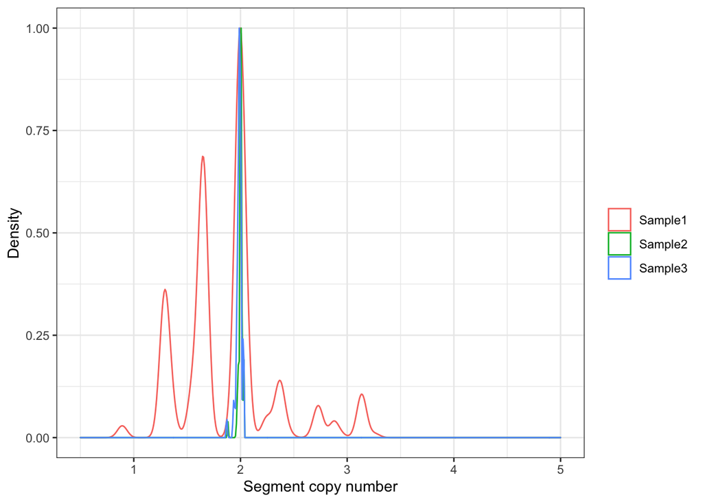

```r
#Plot the CN distribution of each sample to gain a quick overview
ggplot(reshape2::melt(seg.df), aes(x=value,y=..scaled.., colour=variable)) +
  geom_density(adjust=1) +
  theme_bw() + scale_x_continuous(limits=c(0.5, 5)) +
  labs(x='Segment copy number',y='Density',colour='')
```

## 1.2 Generate ensemble segments

Generate a dataframe of ensemble segments contiguous sections of bins that are constant in ALL samples.

```r
segchange <- sapply(1:(nrow(seg.df)-1),
                    function(i) sum(seg.df[i,]!=seg.df[(i+1),])>0)
seg.data <- data.frame(start=c(1,which(segchange)+1),
                       end=c(which(segchange),length(segchange)+1))
seg.data$length <- seg.data$end - seg.data$start+1
```

Filter out small segments and update their values by fitting a normal distribution to bins in the segment. **Here, liquidCNA filters out segments smaller than 6M bases (i.e., 12 500kb bins)**

```r
#Filter segment
seg.sub <- subset(seg.data, length>12) #12 500kb bins
cat('Total number of segments retained: ',nrow(seg.sub))
```

```
## Total number of segments retained:  44
```

```r
#Update segment
seg.fit <- getNormalFitSegments(seg.sub, cn.df)
```

[output not shown]

```r
seg.cns <- seg.fit[[1]]
names(seg.cns) <- names(seg.df)

seg.df.upd <- data.frame(matrix(NA, ncol=ncol(seg.df), nrow=nrow(seg.df)))
names(seg.df.upd) <- names(seg.df); row.names(seg.df.upd) <- row.names(seg.df)

for(i in 1:nrow(seg.sub)){
  seg.df.upd[seg.sub$start[i]:seg.sub$end[i],] <- seg.cns[i,]
}
```

# Purity Estimation

Parameters for purity estimation. **How do we set the first two parameters. Especially the first one, do we have any prior information that can help us set this?**

```r
w = c(0.3,1,0.8,0.15,0.05) #weights of different CN states
maxCN=8 #assumed maximum CN
adjVec = c(0.5,0.6,0.8,0.9,1,1.2,1.3,1.5,1.8,2) #smoothing kernel adjustments
pVec = seq(0.05, 0.5, by=0.005) #range of purity values to be evaluated
```

Estimated optimal purity values are those that minimise mean and median. Optimal purities stored in pHat.df.

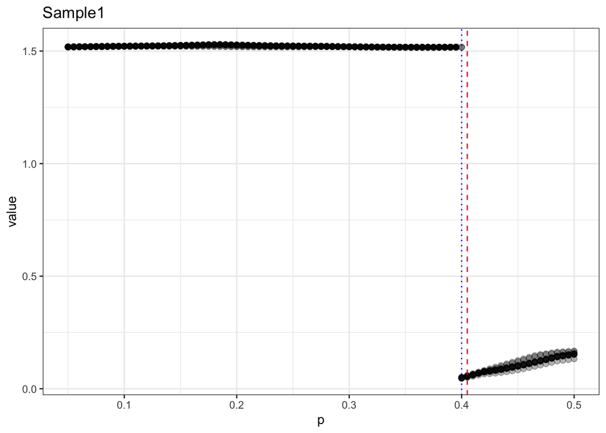

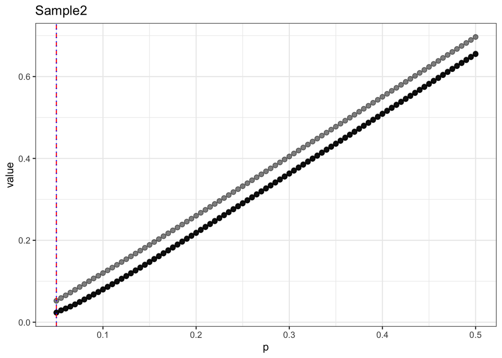

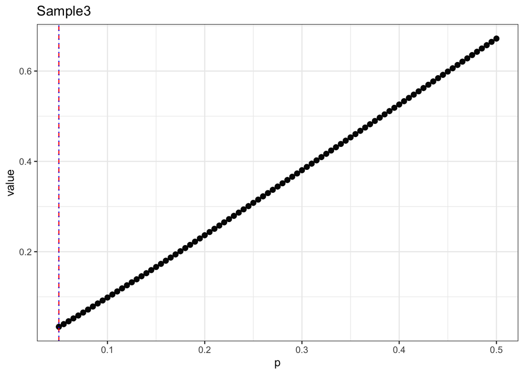

```
## Estimated purity values:
```

```
##        Sample1 Sample2 Sample3
## mean     0.405    0.05    0.05
## median   0.400    0.05    0.05
```

```r
pHat.df <- data.frame(matrix(vector(),ncol=ncol(seg.df.upd), nrow=2))
names(pHat.df) <- names(seg.df.upd)
row.names(pHat.df) <- c('mean','median')
for(i in 1:ncol(seg.df.upd)){
  x <- na.omit(seg.df.upd[,i])
  pFits <- as.data.frame(sapply(adjVec,
                                function(a) sapply(pVec,
                                                   function(p) evalPurityDensity(p,w,a,x,maxCN))))
  pFits$p <- pVec
  mins <- c(pVec[which.min(apply(pFits[,1:length(adjVec)],1,mean))],
            pVec[which.min(apply(pFits[,1:length(adjVec)],1,median))])
  plF <- ggplot(melt(pFits,id='p'), aes(x=p, y=value)) + geom_point(size=2, alpha=0.3)+
    theme_bw() +
    geom_vline(xintercept = mins, linetype=c('dashed','dotted'), colour=c('red','blue')) +
    labs(title=names(seg.df.upd)[i])
  print(plF)
  pHat.df[,names(seg.df.upd)[i]] <- mins
}
```

## Correct CN values by purity

Correct segment CN values (stored in seg.df.upd and seg.cns) with the computed purities using equation:

- CN_corr = 1/p * (CN-2) + 2

```r
pVec <- as.numeric(pHat.df[1,,drop=T])
seg.df.corr <- as.data.frame(t(t(seg.df.upd-2)*1/pVec)+2)
seg.cns.corr <- as.data.frame(t(t(seg.cns-2)*1/pVec)+2)
```

Optional filtering of samples with low filtering. **Overall, samples in our data seems to have low purity. Would this need extra consideration?**

```r
purity_threshold <- 0
abovePurTh <- pVec >= purity_threshold
seg.df.corr <- seg.df.corr[,abovePurTh]
seg.cns.corr <- seg.cns.corr[,abovePurTh]
```

Plot purity-corrected segment distribution:

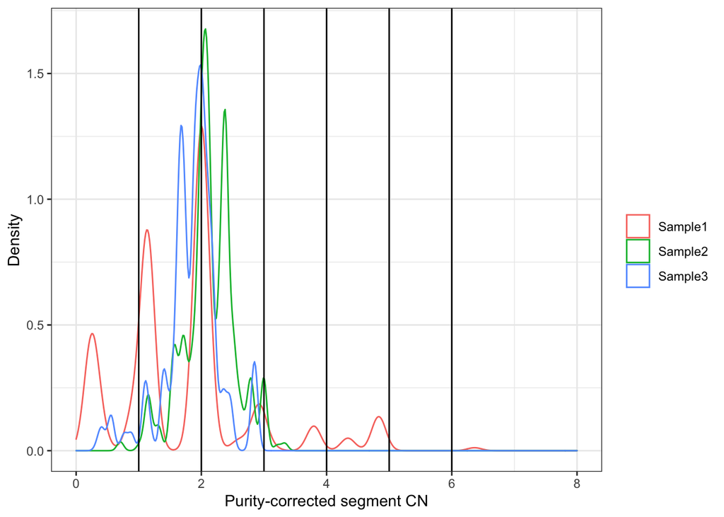

```r
ggplot(melt(as.data.frame(seg.df.corr)), aes(x=value, colour=variable)) +
  geom_density(adjust=1) + theme_bw() +
  scale_x_continuous(limits=c(0,8)) + geom_vline(xintercept = 1:6) +
  labs(x='Purity-corrected segment CN',y='Density',colour='')
```

# Derive sample order and subclonal segments

## Designate reference sample

Designate reference sample from which deltaCN across samples are calculated. Reference sample selected as “Sample 1” as it is the first sample (date-wise) for every patient.

```r
baseSample <- 'Sample1'
seg.dcn <- seg.cns.corr - seg.cns.corr[,baseSample]
seg.dcn.nonBase <- seg.dcn %>% select(-one_of(baseSample))
```

## Ordering: Permutation of remaining samples

Choose samples to investigate (all non-base samples by default), then generate all possible permutations

```r
colToUse <- names(seg.dcn.nonBase)

nCol <- length(colToUse)
seg.dcn.toOrder <- seg.dcn.nonBase[,colToUse]
ordVec <- permutations(nCol,nCol,colToUse)
```

Set parameters to be used when evaluating sample order and segment monotony

```r
filterMethod <- 'sd'#exclude clonal, sd < theta
cutOffVec <- seq(0.025,0.5,by=0.005) #cut-off values for pre-filtering
epsilon <- 0.05 #error margin for monotony
```

Diagnostic plot:

- plot1: proportion of subclonal segments
- plot2: total number of non-clonal (light blue) and subclonal (dark blue) segments

A typical cut-off ~0.1 is adequate. Too low or too high cut-off will select for noise. Ideal cut-off should have a reasonable number of subclonal segments (5-20), while maximising the subclonal proportion. We can automate choosing of optimal cut off.

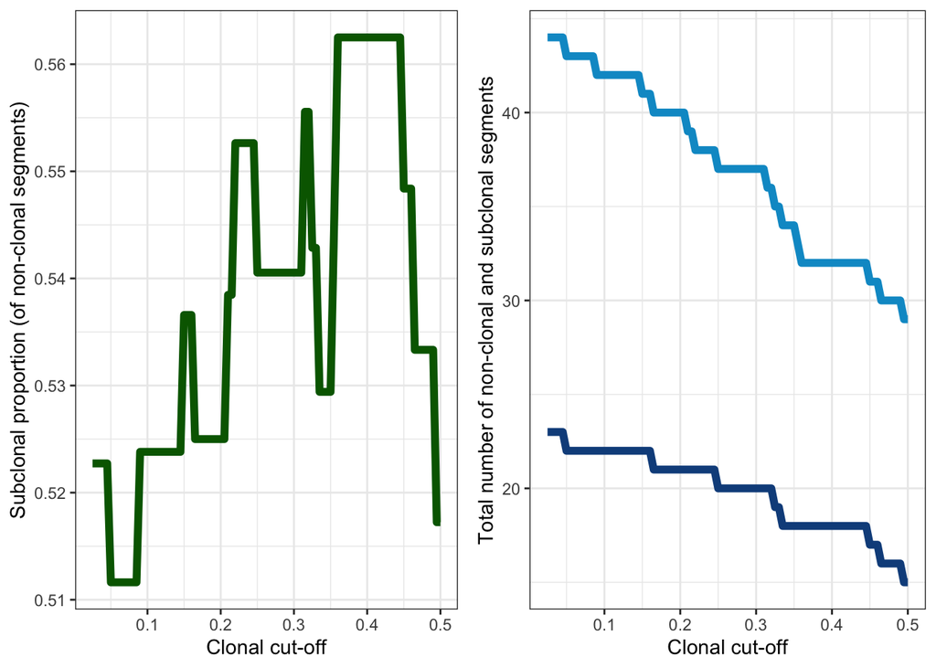

```r
fitInfo <- list()
for (cutOff in cutOffVec){
  seg.dcn.Eval <- filterSegmentRatios(seg.dcn.toOrder, cutOff, filterMethod, 0)
  best <- findBestOrder(seg.dcn.Eval, ordVec, epsilon, nCol, 0)
  fitInfo[[as.character(cutOff)]] <- best
}

fitInfo.df <- data.frame(cutOff = cutOffVec,
                         maxFit = sapply(fitInfo, function(x) x$max),
                         segsAboveCut = sapply(fitInfo, function(x) length(x$cons)),
                         segsInOrder = sapply(fitInfo, function(x) max(sapply(x$segs, length))))
p1 <- ggplot(fitInfo.df, aes(x=cutOff, y=maxFit)) + geom_line(size=2,colour='darkgreen') + theme_bw() +
  labs(x='Clonal cut-off',y='Subclonal proportion (of non-clonal segments)')
p2 <- ggplot(fitInfo.df, aes(x=cutOff, y=segsAboveCut)) + geom_line(size=2,colour='deepskyblue3') +
  geom_line(aes(y=segsInOrder), size=2,colour='dodgerblue4') + theme_bw() +
  labs(x='Clonal cut-off',y='Total number of non-clonal and subclonal segments')
grid.arrange(p1,p2,nrow=1)
```

```r
minSegmentNumber <- 5
recommendCutOff <- getCutOffAuto(fitInfo.df, minSegmentNumber)
cat('Recommended cut-off is: ', recommendCutOff)
```

```
## Recommended cut-off is:  0.36
```

plot DeltaCN for chosen cut off + ordering + segment classification:

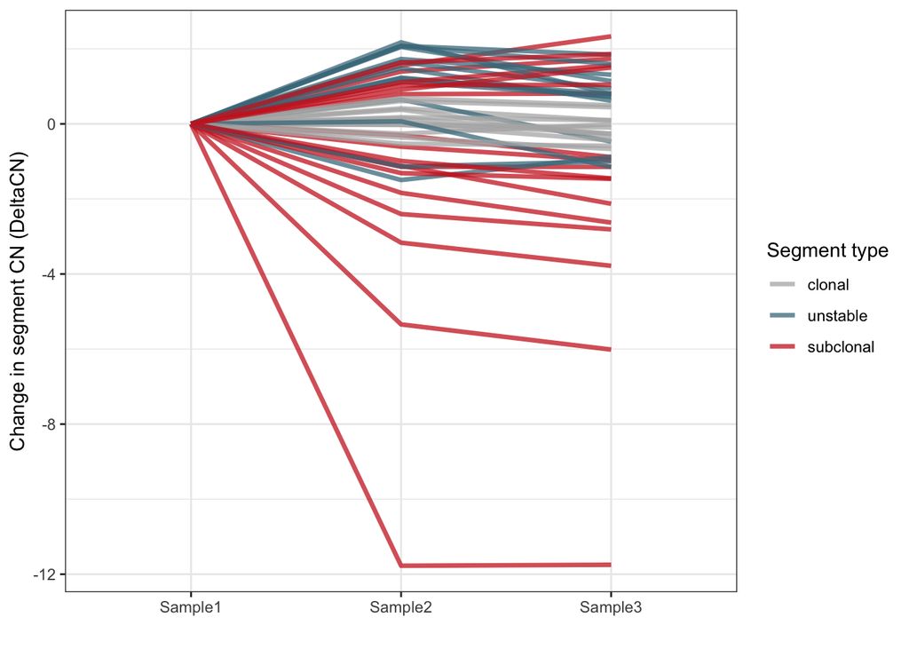

```r
cutOff <- recommendCutOff
fit <- fitInfo[[as.character(cutOff)]]

for (ind in 1:nrow(fit$ord)){
  seg.plot <- seg.dcn[,rev(c(fit$ord[ind,],baseSample))]
  seg.plot$id <- row.names(seg.plot)
  seg.plot$filtered <- seg.plot$id %in% fit$cons
  seg.plot$order <- seg.plot$id %in% fit$segs[[ind]]

  p <- ggplot(melt(seg.plot, id=c('id','filtered','order')), aes(x=variable, y=value, group=id, colour=paste0(filtered,' | ',order))) +
    geom_line(size=1.2, alpha=0.75) + theme_bw() +
    scale_colour_manual(values=c('grey70','#487a8b','firebrick3'), labels=c('clonal','unstable','subclonal')) +
    labs(x='',y='Change in segment CN (DeltaCN)',colour='Segment type')
  print(p)
}
```

if more than one sample order exists:

```r
ordInd <- 1
seg.dcn.toUse <- seg.dcn[fit$segs[[ordInd]],rev(fit$ord[ordInd,])]
```

# Derive Subclonal Ratio

RELATIVE subclonal-ratio is estimated by segment-by-segment comparison to the highest subclonal-ratio sample

```r
topSample <- names(seg.dcn.toUse)[ncol(seg.dcn.toUse)]
toEstimate <- setdiff(names(seg.dcn.toUse), c(topSample,baseSample))

final.ratios <- estimateRSegmentRatio(seg.dcn.toUse, toEstimate, topSample, 1)

final.medians <- aggregate(final.ratios$value,
                           by=list(final.ratios$variable), median)
```

PLOT estimated relative ratios

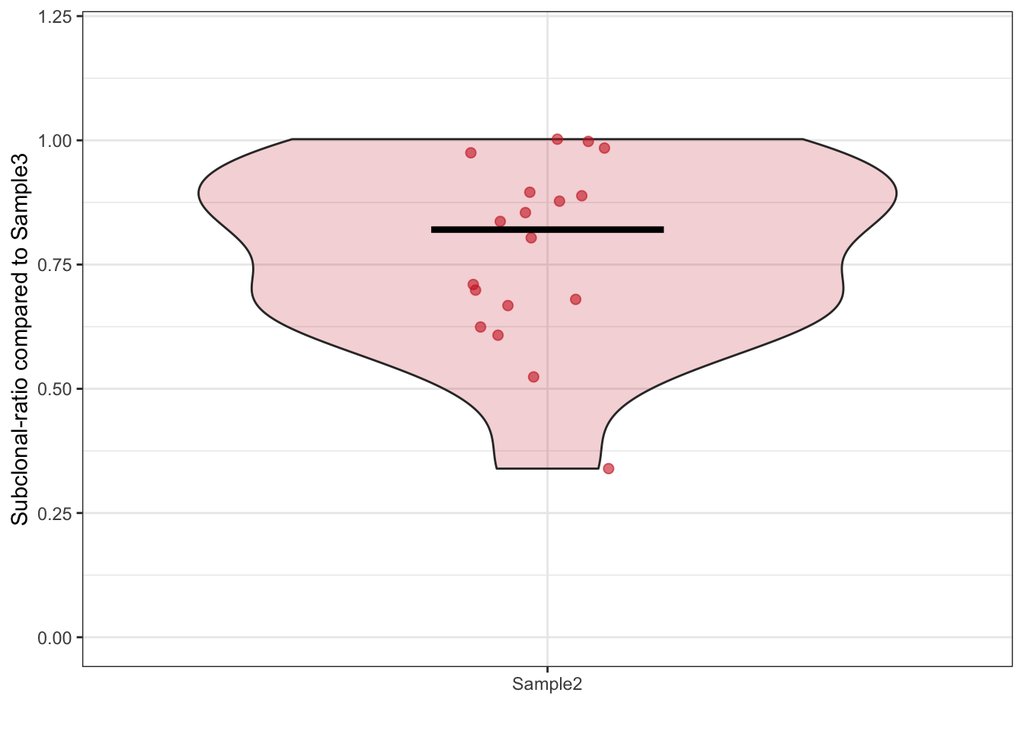

```r
final.medians$xpos <- 1:nrow(final.medians)

ggplot(final.ratios, aes(y=value, x=variable, weight=1)) + geom_violin(fill='firebrick3',alpha=0.2) +
  theme_bw() + scale_y_continuous(limits=c(0,1.2)) +
  geom_jitter(width=0.1, height=0, colour='firebrick3', size=2, alpha=0.6) +
  #geom_point(data=true.df, aes(x=V3, y=V2), colour='firebrick3', size=3) +
  geom_segment(data=final.medians,aes(x=xpos-0.15,xend=xpos+0.15,y=x,yend=x), size=1.5) +
  labs(x='',y=paste0('Subclonal-ratio compared to ',topSample))
```

Package this into final results table of median relative ratio values.

```r
final.results <- aggregate(final.ratios$value, by=list(final.ratios$variable), median)
names(final.results) <- c('time','relratio')
final.results$time <- as.character(final.results$time)
final.results[nrow(final.results)+1,] <- c(topSample, 1)
```

```r
final.results[nrow(final.results)+1,] <- c(baseSample, 0,0,0)
final.results$purity_mean <- as.numeric(pHat.df[1,match(final.results$time,
                                                        names(pHat.df))])
final.results$purity_median <- as.numeric(pHat.df[2,match(final.results$time,
                                                          names(pHat.df))])

cat('Final result table:\n'); print(final.results)
```

```
## Final result table:
```

```
##      time          relratio purity_mean purity_median
## 1 Sample2 0.820317064945191       0.050          0.05
## 2 Sample3                 1       0.050          0.05
## 3 Sample1                 0       0.405          0.40
```